# Project : Customer Revenue Prediction

Jiwon Jeong

September 26, 2018

# Customer Revenue Prediction

## 1. Exloratory Data Anaylsis

This is an Exploratory Data Analysis for the *Google Analytics Customer Revenue Prediction* competition. We are to predict the natural log of the sum of all transactions per user. for every user in the test set, the target is:

$$y_{user} = \sum_{i=1}^n transaction_{user_i}$$

$$target_{user} = ln(y_{user}+1).$$

Submissions are scored on the root mean squared error, which is defined as:

$$RMSE = \sqrt{\frac{1}{n} \sum_{i=1}^n (y_i - \widehat{y_i})^2},$$

where $\widehat{y}$ is the predicted revenue for a customer and $y$ is the natural log of the actual revenue value.

I skipped all the data pre-processing steps I took. All the code and data set for this article are available on [GitHub](https://github.com/jjone36/myKaggle). Okay now let’s have a look at the dataset.

```
## Observations: 903,653
## Variables: 23
## $ channelGrouping    <fct> Organic Search, Organic Search, Organic Sea...
## $ date               <date> 2016-09-02, 2016-09-02, 2016-09-02, 2016-0...
## $ fullVisitorId      <dbl> 1.131660e+18, 3.773060e+17, 3.895546e+18, 4...
## $ sessionId          <fct> 1131660440785968503_1472830385, 37730602087...
## $ visitId            <int> 1472830385, 1472880147, 1472865386, 1472881...
## $ visitNumber        <int> 1, 1, 1, 1, 2, 1, 1, 1, 1, 1, 1, 1, 1, 1, 1...
## $ visitStartTime     <int> 1472830385, 1472880147, 1472865386, 1472881...
## $ browser            <fct> Chrome, Firefox, Chrome, UC Browser, Chrome...
## $ operatingSystem    <fct> Windows, Macintosh, Windows, Linux, Android...
## $ isMobile           <int> 0, 0, 0, 0, 1, 0, 0, 0, 0, 0, 1, 0, 1, 1, 0...
## $ deviceCategory     <fct> desktop, desktop, desktop, desktop, mobile,...
## $ continent          <fct> Asia, Oceania, Europe, Asia, Europe, Europe...
## $ subContinent       <fct> Western Asia, Australasia, Southern Europe,...
## $ country            <fct> Turkey, Australia, Spain, Indonesia, United...
## $ networkDomain      <fct> ttnet.com.tr, dodo.net.au, unknown.unknown,...
## $ hits               <int> 1, 1, 1, 1, 1, 1, 1, 1, 1, 1, 1, 1, 1, 1, 1...
## $ pageviews          <int> 1, 1, 1, 1, 1, 1, 1, 1, 1, 1, 1, 1, 1, 1, 1...
## $ bounces            <int> 1, 1, 1, 1, 1, 1, 1, 1, 1, 1, 1, 1, 1, 1, 1...
## $ newVisits          <int> 1, 1, 1, 1, 0, 1, 1, 1, 1, 1, 1, 1, 1, 1, 1...
## $ transactionRevenue <dbl> NA, NA, NA, NA, NA, NA, NA, NA, NA, NA, NA,...
## $ source             <fct> google, google, google, google, google, goo...
## $ medium             <fct> organic, organic, organic, organic, organic...
## $ keyword            <fct> (not provided), (not provided), (not provid...
```

### 1-1. The target variable : Transaction Revenue

As you can see above, Our target variable ‘transaction Revenue’ has lots of NAs and we can guess they could be deemed as just no transaction occurred. Additionally. the range of the target variable is quite large that it’s better to transform data into log scaled. If we plot the distribution of the ‘logRevenue’, the log-scaled of ‘transaction Revenue’, is like below.

```r
train$logRevenue = log(train$transactionRevenue)
train$logRevenue[is.na(train$logRevenue)] = 0
train = train[, c(24, 1:23)]

summary(train$transactionRevenue, na.rm = T)
```

```
##      Min.   1st Qu.    Median      Mean   3rd Qu.      Max.      NA's
## 1.000e+04 2.493e+07 4.945e+07 1.337e+08 1.077e+08 2.313e+10    892138
```

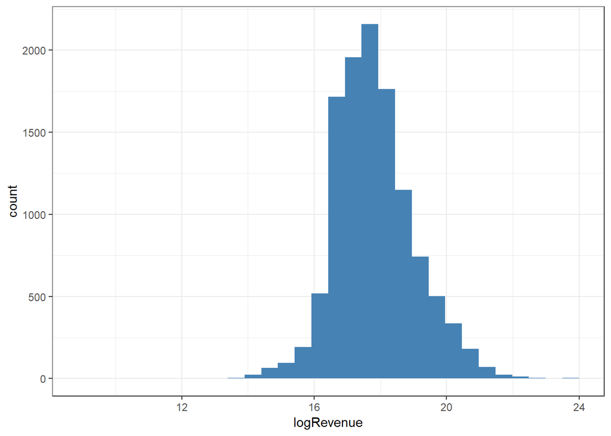

```r
train %>%
  filter(logRevenue > 0) %>%
  ggplot(aes(x = logRevenue)) +
  geom_histogram(fill = 'steelblue') +
  theme_bw()
```

Another variable that catches our eyes is ‘visit Number’, or the number of visit of a user, cause It will definitely related to the interest and purchase of customers. So I will look into the relations of log-scaled transaction Revenue and visit Number with other variables. As like below, most of the ‘visit Number’ are 1 and has exponentially decreasing distribution like below, which I filtered the variable over 100.

```r
summary(train$visitNumber)
```

```
##    Min. 1st Qu.  Median    Mean 3rd Qu.    Max.
##   1.000   1.000   1.000   2.265   1.000 395.000
```

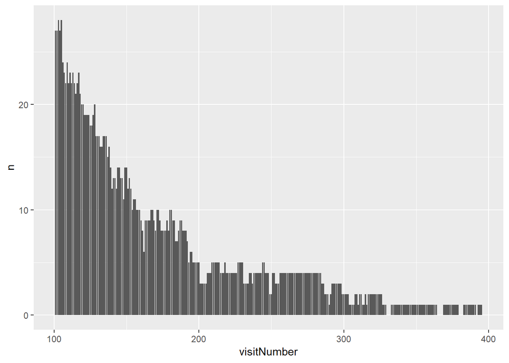

```r
train %>%
  count(visitNumber) %>%
  filter(visitNumber > 100) %>%
  ggplot(aes(x = visitNumber, y = n)) + geom_col()
```

### 2-1. Which channel is the most profitable?

There are 7 major channel groups. Organic search is the most frequently used channel and Social and Direct it the next followers.

```r
table(train$channelGrouping)
```

```
##
##        (Other)     Affiliates         Direct        Display Organic Search
##            120          16403         143026           6262         381561
##    Paid Search       Referral         Social
##          25326         104838         226117
```

```r
myTheme = theme(axis.text.x = element_text(angle = 45, hjust = 1),
                panel.background = element_rect(fill = 'white', color = 'grey50'),
                panel.grid.major = element_line(color = 'grey90'))
```

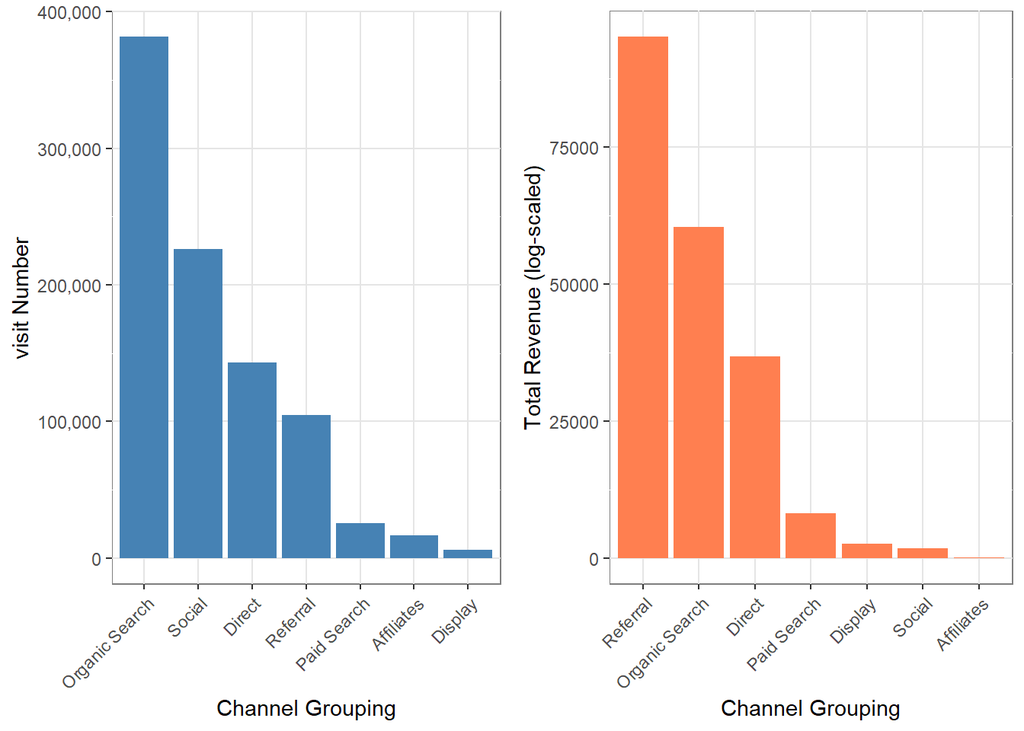

```r
cg_p1 = train %>%
  group_by(channelGrouping) %>%
  filter(channelGrouping != '(Other)') %>%
  count() %>%
  ggplot(aes(x = reorder(channelGrouping, -n), y = n)) +
  geom_col(fill = 'steelblue') +
  scale_y_continuous(labels = scales::comma) +
  labs(x = 'Channel Grouping', y = 'visit Number') +
  myTheme

cg_p2 = train %>%
  group_by(channelGrouping) %>%
  filter(channelGrouping != '(Other)') %>%
  summarise(total_revenue = sum(logRevenue, na.rm = T)) %>%
  arrange(desc(total_revenue)) %>%
  ggplot(aes(x = reorder(channelGrouping, -total_revenue), y = total_revenue)) +
  geom_col(fill = 'coral') +
  labs(x = 'Channel Grouping', y = 'Total Revenue (log-scaled)') +
  myTheme

grid.arrange(cg_p1, cg_p2, ncol = 2)
```

The box plot below tells us the range of revenue per each channel. Please remember this is log-scaled revenue, so the small difference in the plot has large difference in real transaction revenue.

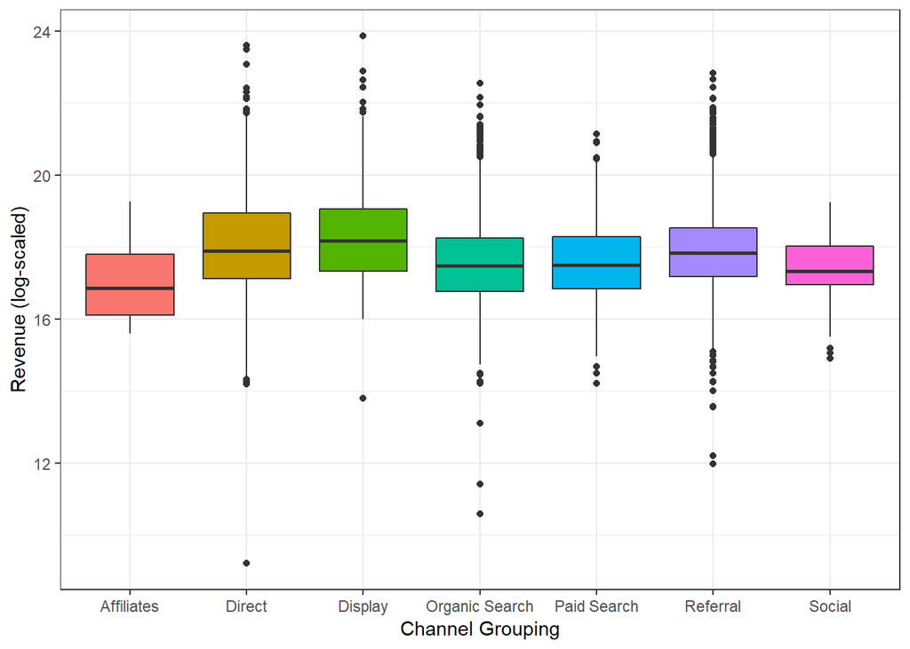

```r
train %>%
  filter(channelGrouping != '(Other)', logRevenue > 0) %>%
  ggplot(aes(x = channelGrouping, y = logRevenue, fill = channelGrouping)) +
  geom_boxplot(show.legend = F) +
  labs(x = 'Channel Grouping', y = 'Revenue (log-scaled)') +
  theme_bw()
```

### 2-2. Which device do the users prefer?

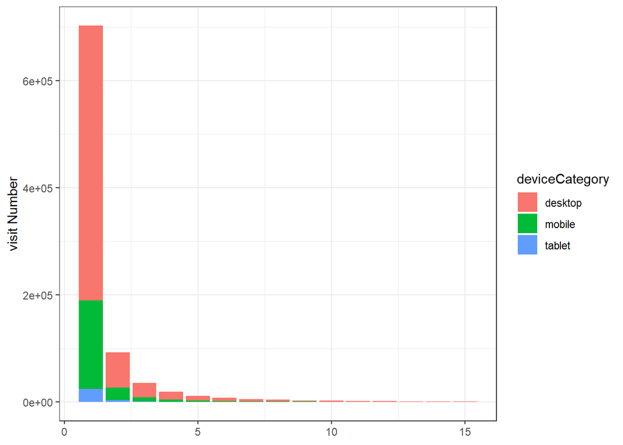

```r
train %>%
  group_by(deviceCategory) %>%
  count(visitNumber) %>%
  arrange(desc(n)) %>%
  top_n(n = 15, wt = n) %>%
  ggplot(aes(x = visitNumber, y = n, fill = deviceCategory)) +
  geom_col() +
  labs(x = NULL, y = 'visit Number') +
  theme_bw()
```

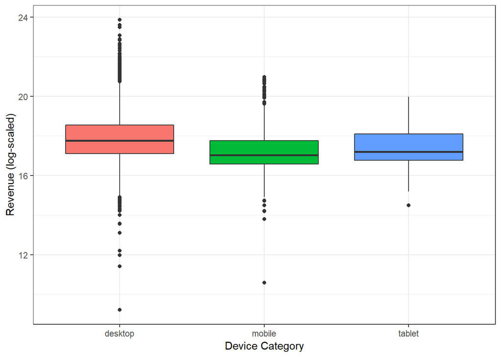

```r
train %>%
  filter(logRevenue>0) %>%
  ggplot(aes(x = deviceCategory, y = logRevenue, fill = deviceCategory)) +
  geom_boxplot(show.legend = F) +
  labs(x = 'Device Category', y = 'Revenue (log-scaled)') +
  theme_bw()
```

### 2-3. Who are the major users?

Where are the users coming from? As we can see, and quite obviously, majority of the users are Americans. Asian and European are following the next.

```r
table(train$continent)
```

```
##
## (not set)    Africa  Americas      Asia    Europe   Oceania
##      1468     14745    450377    223698    198311     15054
```

When we take a look at revenue per each continent, we can see interesting point in Africa. Considering the visit number of Africa is the smallest, African users give a huge scale of profit to Gstore.

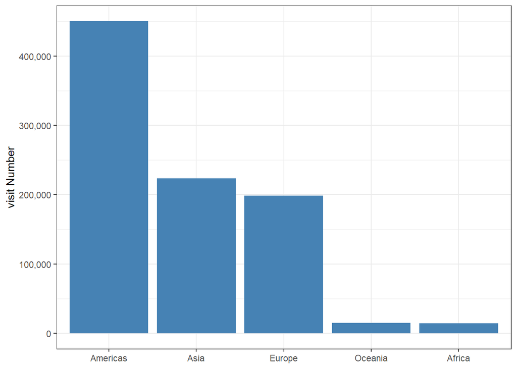

```r
train %>%
  group_by(continent) %>%
  filter(continent != '(not set)') %>%
  count() %>%
  ggplot(aes(x = reorder(continent, -n), y = n)) +
  geom_col(fill = 'steelblue') +
  scale_y_continuous(labels = scales::comma) +
  labs(x = NULL, y = 'visit Number') +
  theme_bw()
```

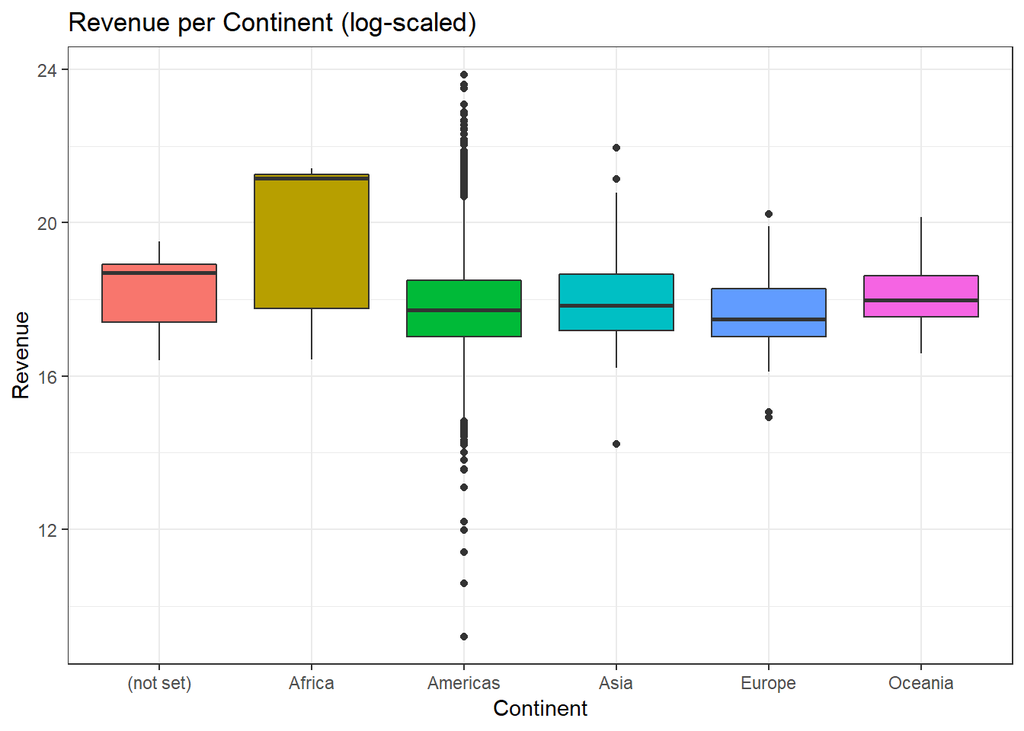

```r
train %>%
  filter(logRevenue > 0) %>%
  ggplot(aes(x = continent, y = logRevenue, fill = continent)) +
  geom_boxplot(show.legend = F) +
  labs(x = 'Continent', y = 'Revenue', title = 'Revenue per Continent (log-scaled)') +
  theme_bw()
```

The revenue over time per each continent has various distributions like below and America has the most distinct shape compared to other continent.

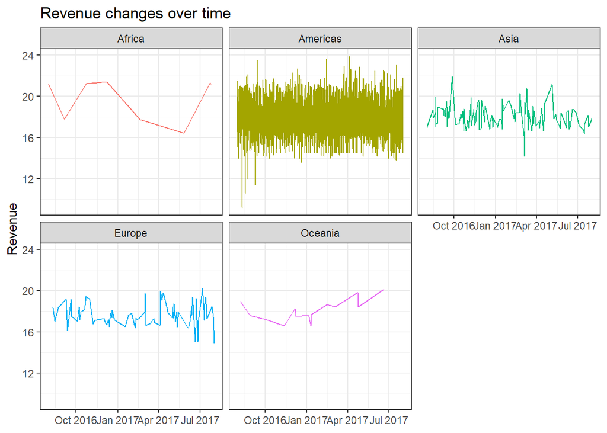

```r
train %>%
  filter(continent != '(not set)', logRevenue>0) %>%
  ggplot(aes(x = date, y = logRevenue, color = continent)) +
  geom_line(show.legend = F, size = .5) +
  facet_wrap(continent~.) +
  labs(x = NULL, y = 'Revenue', title = 'Revenue changes over time') +
  theme_bw()
```

If we see closer to each sub continent in America, the most of the transaction occurs in Northern America and that time distribution of America is same with that of Northern America.

```r
train %>%
  filter(continent == 'Americas', logRevenue > 0) %>%
  group_by(subContinent) %>%
  count() %>%
  arrange(desc(n))
```

```
## # A tibble: 4 x 2
## # Groups:   subContinent [4]
##   subContinent         n
##   <fct>            <int>
## 1 Northern America 11143
## 2 South America       98
## 3 Central America     26
## 4 Caribbean           16
```

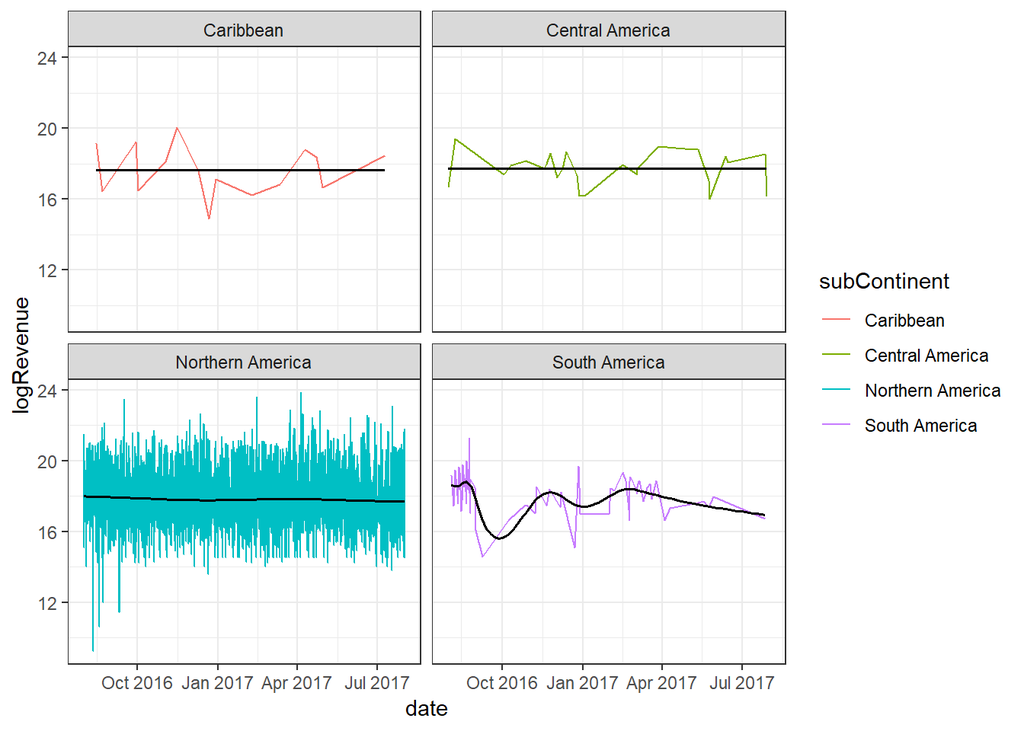

```r
train %>%
  filter(continent == 'Americas', logRevenue>0) %>%
  ggplot(aes(x = date, y = logRevenue, col = subContinent)) +
  geom_line() +
  geom_smooth(color = 'black', se = F, size = .7) +
  facet_wrap(.~subContinent, nrow = 2) +
  theme_bw()
```

### 2-4. When is the high season of Gstore?

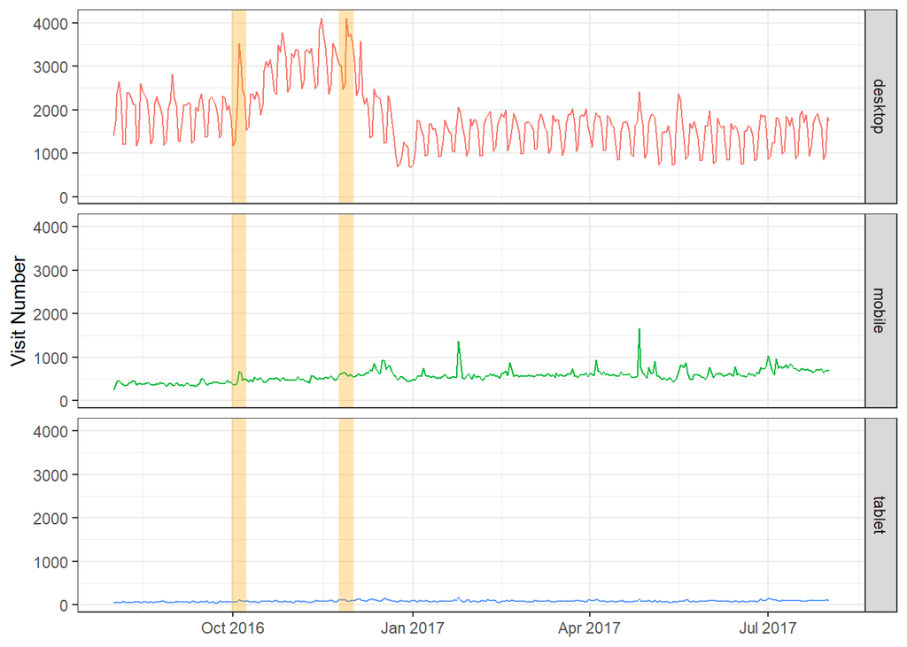

```r
train %>%
  group_by(date, deviceCategory) %>%
  count() %>%
  ggplot(aes(x = date, y = n, col = deviceCategory)) +
  geom_line(show.legend = F) +
  facet_grid(deviceCategory~ ., space = 'free_y') +
  geom_vline(xintercept = as.Date(c('2016-10-4', '2016-11-28')),
             color = 'Orange', size = 4, alpha = .3) +
  labs(x = NULL, y = 'Visit Number') +
  theme_bw()
```

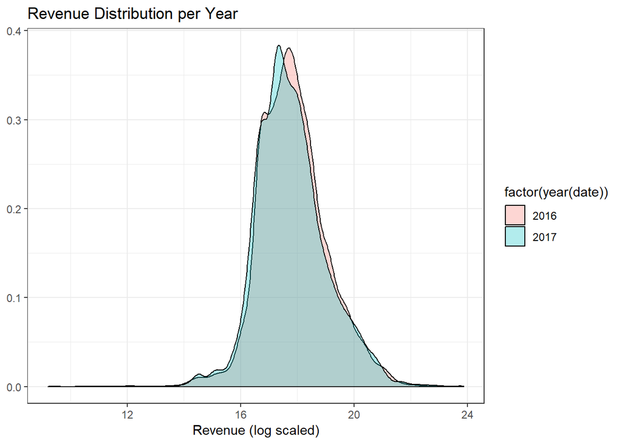

```r
train %>%
  filter(logRevenue > 0) %>%
  group_by(year(date)) %>%
  ggplot(aes(x = logRevenue, fill = factor(year(date)))) +
  geom_density(alpha = .3) +
  labs(x = "Revenue (log scaled)", y = NULL, title = "Revenue Distribution per Year") +
  theme_bw()
```

```r
train %>%
  group_by(year(date)) %>%
  summarise(median = median(transactionRevenue, na.rm = T),
            mean = mean(transactionRevenue, na.rm = T))
```

```
## # A tibble: 2 x 3
##   `year(date)`   median       mean
##          <dbl>    <dbl>      <dbl>
## 1         2016 52050000 129279371.
## 2         2017 46370000 137375621.
```

The density plot of revenue has similar shape in 2016 and 2017. But there a small difference in mean values, which becomes a quite considerable gap when it’s considered in actual scale.

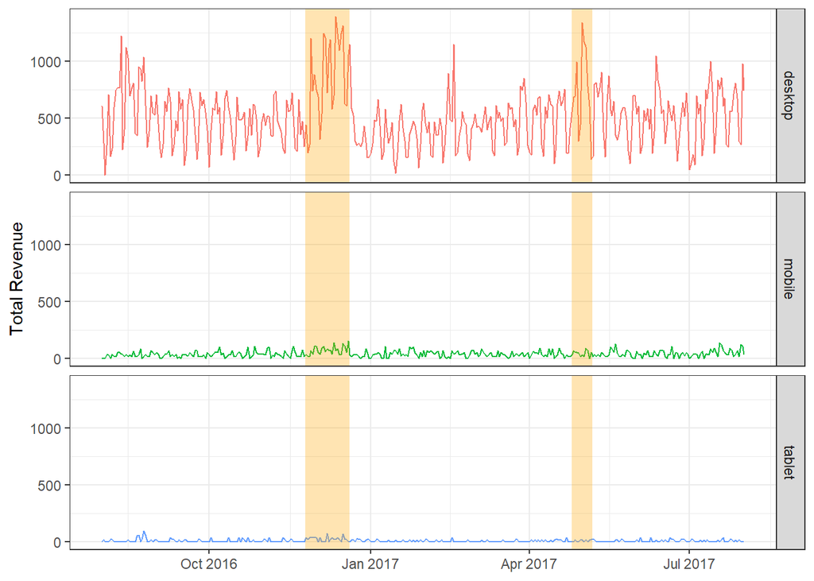

```r
train %>%
  group_by(date, deviceCategory) %>%
  summarise(total_revenue = sum(logRevenue)) %>%
  ggplot(aes(x = date, y = total_revenue, col = deviceCategory)) +
  geom_line(show.legend = F) +
  facet_grid(deviceCategory ~., space = 'free_y') +
  geom_vline(xintercept = as.Date('2016-12-07'),
             color = 'Orange', size = 13, alpha = .3) +
  geom_vline(xintercept = as.Date('2017-05-01'),
             color = 'Orange', size = 6, alpha = .3) +
  labs(x = NULL, y = 'Total Revenue') +
  theme_bw()
```

```r
train %>%
  filter(deviceCategory == 'desktop') %>%
  group_by(date) %>%
  summarise(total_revenue = sum(logRevenue)) %>%
  arrange(desc(total_revenue)) %>%
  head(10)
```

```
## # A tibble: 10 x 2
##    date       total_revenue
##    <date>             <dbl>
##  1 2016-12-12         1393.
##  2 2017-05-01         1341.
##  3 2016-12-16         1314.
##  4 2016-12-05         1246.
##  5 2016-12-15         1245.
##  6 2016-12-13         1243.
##  7 2016-08-12         1222.
##  8 2016-12-06         1209.
##  9 2016-11-28         1204.
## 10 2016-12-09         1194.
```

The total revenue over the time period has the two peak time at first week of December and May. If we continue to think with the plot we saw with the number of visit verse time, people seem to start surfing the web from Octorber and make actual purchases from the last week of Noverbem. There is another peak on first week of May although we have no clue what happened during that period. The actual transaction revenue and its time can be seen like above.

### 2-5. When do the uses usually order google swag products?

If we see when the uses are usually to make an order during a week, we can find the amount of visit number or revenue during weekend is lower than that of weekdays. As a person who has a habit to put things in my cart during weekend and purchase them all at once on weekend, this is somewhat unexpected result for me.

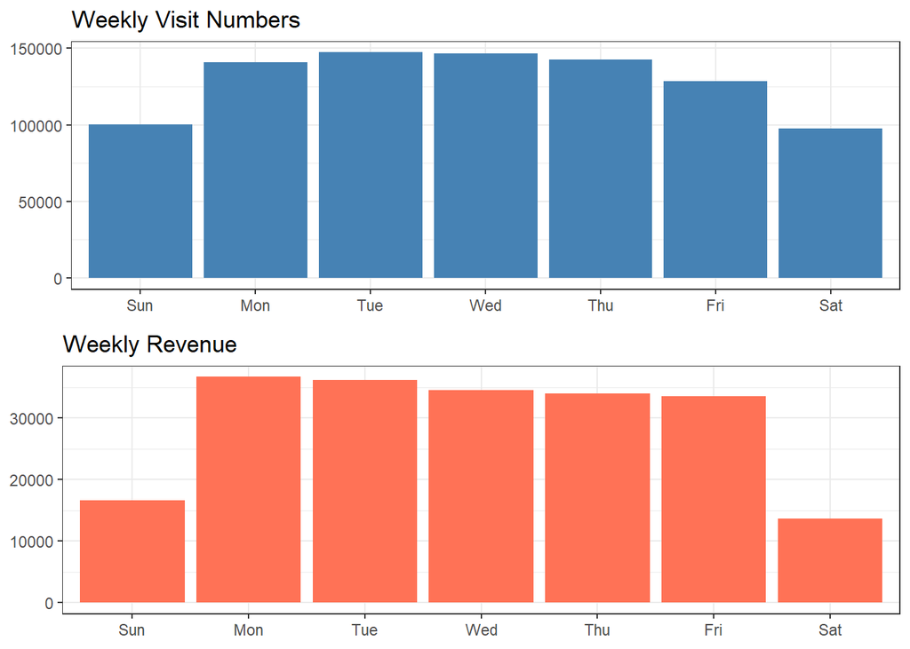

```r
weekly_p1 = train %>%
  group_by(weekday = wday(date, label = T)) %>%
  count() %>%
  ggplot(aes(x = weekday, y = n)) +
  geom_col(fill = 'steelblue') +
  labs(x = NULL, y = NULL, title = 'Weekly Visit Numbers') +
  theme_bw()

weekly_p2 = train %>%
  group_by(weekday = wday(date, label = T)) %>%
  summarise(total_revenue = sum(logRevenue, na.rm = T)) %>%
  ggplot(aes(x = weekday, y = total_revenue)) +
  geom_col(fill = 'coral1') +
  labs(x = NULL, y = NULL, title = 'Weekly Revenue') +
  theme_bw()

grid.arrange(weekly_p1, weekly_p2, nrow = 2)
```

### 2-6. What browsers are the major web sites?

Most of the users use Chrome and Safari for their browser. The gap between chrome and any other browsers are so large that I compared the difference of revenue divided by the number of visits per each browser. Consequently we can see aother trends among browsers except the fact that Chrome is the highest. Although the number of visit by Edge is low, the proportional revenue comes to the second major browser.

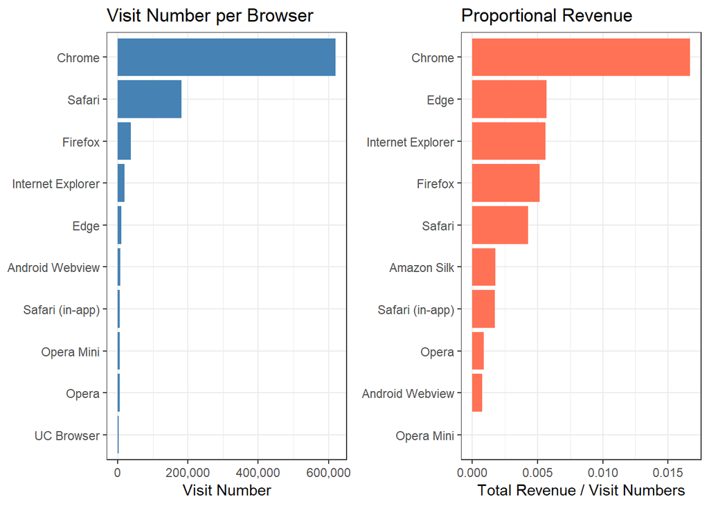

```r
browser_n = train %>%
  filter(!is.na(browser)) %>%
  group_by(browser) %>%
  count() %>%
  arrange(desc(n))

browser_p1 = browser_n[1:10, ] %>%
  ggplot(aes(x = reorder(browser, n), y = n)) +
  geom_col(fill = 'steelblue') +
  coord_flip() +
  scale_y_continuous(labels = scales::comma) +
  labs(y = 'Visit Number', x = NULL, title = 'Visit Number per Browser') +
  theme_bw()

browser_p2 = train %>%
  group_by(browser) %>%
  summarise(total_revenue = sum(logRevenue>0)) %>%
  right_join(browser_n) %>%
  mutate(prop_revenue = total_revenue / n) %>%
  arrange(desc(prop_revenue)) %>%
  head(10) %>%
  ggplot(aes(x = reorder(browser, prop_revenue), y = prop_revenue)) +
  geom_col(fill = 'coral1') +
  coord_flip() +
  labs(y = 'Total Revenue / Visit Numbers', x = NULL, title = 'Proportional Revenue') +
  theme_bw()

grid.arrange(browser_p1, browser_p2, ncol = 2)
```

### 2-7. Do the operation systems have any tendency among the users?

I also compared the proportional revenue for the operation systems like I did with browsers, and again, there are some changes in orders of operations systems like below.

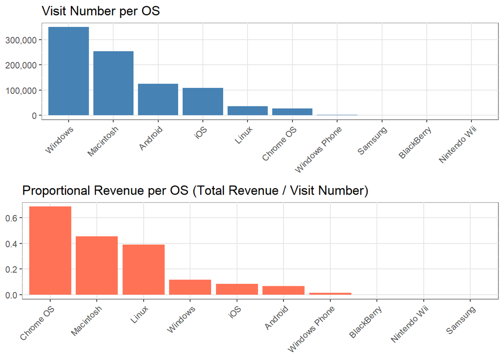

```r
os_n = train %>%
  filter(operatingSystem != '(not set)') %>%
  group_by(operatingSystem) %>%
  count() %>%
  arrange(desc(n))

os_p1 = os_n[1:10, ] %>%
ggplot(aes(x = reorder(operatingSystem, -n), y = n)) +
  geom_col(fill = 'steelblue') +
  scale_y_continuous(labels = scales::comma) +
  labs(x = NULL, y = NULL, title = 'Visit Number per OS') +
  myTheme

os_p2 = train %>%
  group_by(operatingSystem) %>%
  summarise(total_revenue = sum(logRevenue, na.rm = T)) %>%
  right_join(os_n) %>%
  mutate(prop_revenue = total_revenue / n) %>%
  arrange(desc(prop_revenue)) %>%
  head(10) %>%
  ggplot(aes(x = reorder(operatingSystem, -prop_revenue), y = prop_revenue)) +
  geom_col(fill = 'coral1') +
  labs(x = NULL, y = NULL, title = 'Proportional Revenue per OS (Total Revenue / Visit Number)') +
  myTheme

grid.arrange(os_p1, os_p2, nrow = 2)
```

### 2-8. What about sources, mediums and Keywords?

There are large number of variance in soruces in raw dataset, so I cleaned them up into smaller categories. After integrating and filtering, we can see that major sources are google and youtube. When it comes to medium, organic and referral are the two top. Keyword seems not that nutritious variable for predicting transaction revenue for little information.

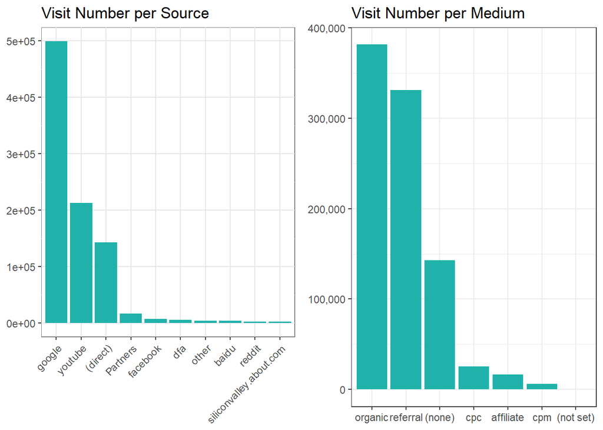

```r
p_s = train %>%
  group_by(source) %>%
  count() %>%
  arrange(desc(n)) %>%
  head(10) %>%
  ggplot(aes(x = reorder(source, -n), y = n)) +
  geom_col(fill = 'lightseagreen') +
  labs(x = NULL, y = NULL, title = 'Visit Number per Source') +
  myTheme

p_m = train %>%
  group_by(medium) %>%
  count() %>%
  arrange(desc(n)) %>%
  head(10) %>%
  ggplot(aes(x = reorder(medium, -n), y = n)) +
  geom_col(fill = 'lightseagreen') +
  scale_y_continuous(labels = scales::comma) +
  labs(x = NULL, y = NULL, title = 'Visit Number per Medium') +
  theme_bw()

grid.arrange(p_s, p_m, nrow = 1)
```

```r
train %>%
  filter(!is.na(keyword) & keyword != '(not provided)') %>%
  group_by(keyword) %>%
  count() %>%
  arrange(desc(n)) %>%
  head(10)
```

```
## # A tibble: 10 x 2
## # Groups:   keyword [10]
##    keyword                             n
##    <fct>                           <int>
##  1 6qEhsCssdK0z36ri                11503
##  2 (Remarketing/Content targeting)  2298
##  3 1hZbAqLCbjwfgOH7                 2264
##  4 google merchandise store         2209
##  5 Google Merchandise               1648
##  6 google store                     1277
##  7 youtube                           568
##  8 (User vertical targeting)         489
##  9 1X4Me6ZKNV0zg-jV                  467
## 10 (automatic matching)              427
```

### 2-9. Is there any tendency

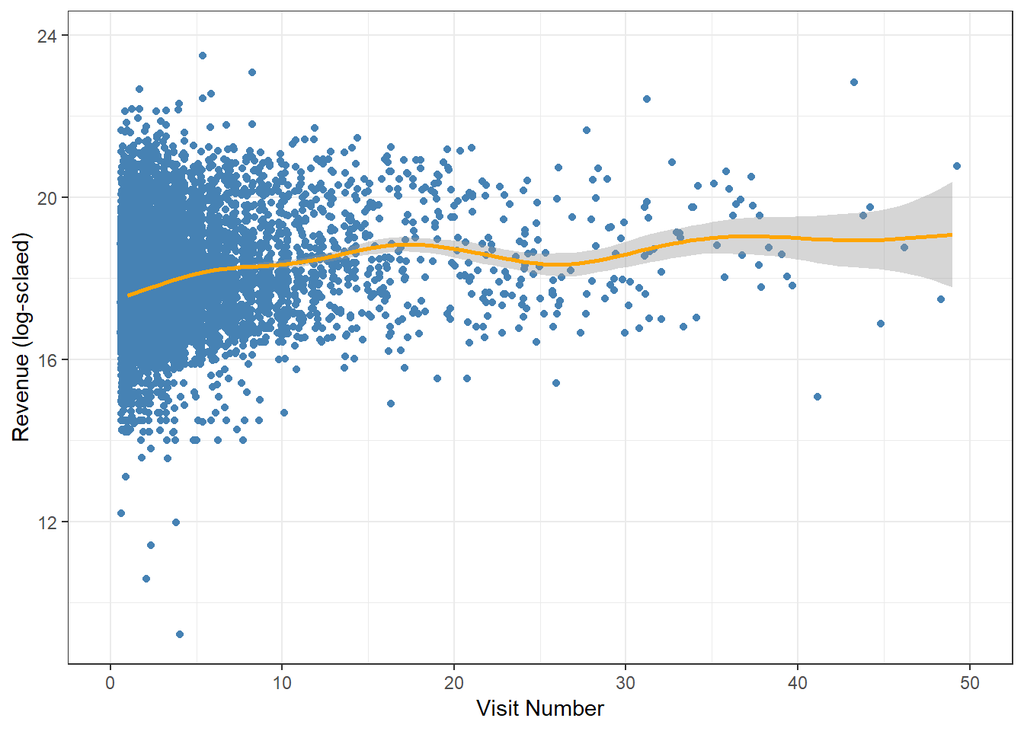

```r
train %>%
  filter(logRevenue>0) %>%
  ggplot(aes(x = visitNumber, y = logRevenue)) +
  geom_jitter(color = 'steelblue') +
  geom_smooth(color = 'Orange') +
  scale_x_continuous(limits = c(0, 50)) +
  labs(x = 'Visit Number', y = 'Revenue (log-sclaed)') +
  theme_bw()
```

## Conclusion

We walked through several variables and the relationships with visit numbers and revenue so far. The device categories, browsers, and operation systems have some preferences among customers. The revenue scale has a significant difference according to regions like countries and continents. Lastly time is highly related to the visit numbers and revenue. There are high seasons during a year and people tend to make a purchase on certain weekdays. Therefore, in feature engineering, splitting the time into parts is required for the accuracy of fitting.